# 1.Motivation

## Introduction

San Francisco is widely recognized as one of the most developed cities in the world and is a top tourist destination in the USA, attracting millions of visitors each year with its iconic landmarks, museums, cultural events, and scenic views. But San Francisco, like any city, has its share of crime and safety concerns. While it has a relatively high crime rate compared to other cities in the USA, which can have negative impacts on both the tourism industry and the safety of its residents.San Francisco's high crime rate is a complex issue that requires careful analysis and consideration. While the city has implemented various measures to improve public safety, including increasing police presence and community engagement, there are still several factors that contribute to the high crime rate. These include socio-economic disparities, drug use, and a large homeless population. Understanding these underlying issues is crucial to developing effective strategies to address crime and improve public safety in San Francisco.

Lets play the role of an analyst in a police station, as analysts in a police station, we can use data-driven approaches such as crime mapping and statistical analysis to identify patterns and trends, which can help inform policy decisions and resource allocation. Our work is essential in ensuring that San Francisco remains a vibrant and safe city for both its residents and visitors.

## Objectives

The objective of this study is to analyze the incidence of different types of crimes that have occurred in San Francisco in recent years. By using data visualization techniques, we aim to identify any noteworthy patterns and gain insightful information that can improve our understanding of crime trends. Ultimately, this study aims to help develop more effective strategies for crime prevention and control in the city.Our objective can be divided into following three parts:

- *Analyze the trend of crime incidents for each type of crime in recent years, and identify which types have consistently increased. This will allow us to focus on these particular crime types*
- *Utilize map visualization to analyze a specific type of crime.*
- *Utilize interactive visualization in Bokeh to analyze a specific type of crime.*

# 2.Basic Stats

Prior to conducting the actual analysis, data cleansing and preprocessing are performed. The first step involves loading the necessary packages.

```python
import pandas as pd
import numpy as np
import folium
from folium.plugins import HeatMap
from folium import plugins
import seaborn as sns
import random
from bokeh.io import output_notebook, show
from bokeh.models import ColumnDataSource, FactorRange, Legend
from bokeh.plotting import figure
from urllib.request import urlopen
import json
from scipy import stats
import matplotlib.pyplot as plt
from skimage import color, io, measure, img_as_ubyte
import calplot
from datetime import datetime
import calendar
import locale
from bokeh.plotting import figure, output_file, save
```

Before proceeding with data analysis and visualization, it is necessary to preprocess the dataset to meet our requirements.

```python
df = pd.read_csv("./Police_Department_Incident_Reports__Historical_2003_to_May_2018.csv")
focuscrimes = set(['WEAPON LAWS', 'PROSTITUTION', 'DRIVING UNDER THE INFLUENCE', 'ROBBERY', 'BURGLARY', 'ASSAULT', 'DRUNKENNESS', 'DRUG/NARCOTIC', 'TRESPASS', 'LARCENY/THEFT', 'VANDALISM', 'VEHICLE THEFT', 'STOLEN PROPERTY', 'DISORDERLY CONDUCT'])
df_focus = df[df["Category"].isin(focuscrimes)]
```

```python
df_focus["Year"] = df_focus["Date"].apply(lambda x:x.split('/')[2])
df_focus = df_focus[df_focus["Year"].isin([str(i) for i in range(2010,2018)])]
```

# 3.Data Analysis

## Year Pattern

Now that we have completed data preprocessing, we will utilize visualization tools to gain insights into the trends of different types of crimes that have occurred in recent years. Our objective is to identify the types of crimes that have been consistently increasing and those that have been successfully controlled.

```python
focusdf = df_focus[['Category','Year']].copy()
counts = focusdf[focusdf['Category'].isin(focuscrimes)].groupby(['Year','Category']).size().reset_index(name='counts')
pivot = counts.pivot(index = 'Category', columns = 'Year',values = 'counts')
```

```python
pivot
```

| Year Category | 2010 | 2011 | 2012 | 2013 | 2014 | 2015 | 2016 | 2017 |
| --- | --- | --- | --- | --- | --- | --- | --- | --- |
| ASSAULT | 10659 | 10589 | 10519 | 10790 | 10398 | 11090 | 11546 | 11613 |
| BURGLARY | 4942 | 4927 | 6197 | 6160 | 6033 | 5903 | 5791 | 5828 |
| DISORDERLY CONDUCT | 815 | 752 | 699 | 459 | 343 | 547 | 657 | 395 |
| DRIVING UNDER THE INFLUENCE | 457 | 466 | 421 | 447 | 379 | 428 | 377 | 299 |
| DRUG/NARCOTIC | 9036 | 6802 | 6307 | 6672 | 5324 | 4194 | 4202 | 3265 |
| DRUNKENNESS | 701 | 646 | 640 | 951 | 617 | 576 | 465 | 337 |
| LARCENY/THEFT | 24212 | 25629 | 30760 | 36216 | 37860 | 41980 | 40365 | 47714 |
| PROSTITUTION | 1281 | 1078 | 678 | 678 | 449 | 370 | 635 | 523 |
| ROBBERY | 3232 | 3218 | 3850 | 4064 | 3344 | 3697 | 3230 | 3265 |
| STOLEN PROPERTY | 649 | 748 | 878 | 1171 | 1058 | 927 | 861 | 782 |
| TRESPASS | 1130 | 1051 | 1262 | 1113 | 1111 | 1395 | 1807 | 1607 |
| VANDALISM | 7743 | 7077 | 7704 | 6833 | 7102 | 7636 | 8557 | 9719 |
| VEHICLE THEFT | 4336 | 4743 | 6174 | 6234 | 7101 | 7935 | 6417 | 5705 |
| WEAPON LAWS | 1243 | 1184 | 1358 | 1435 | 1478 | 1590 | 1591 | 1644 |

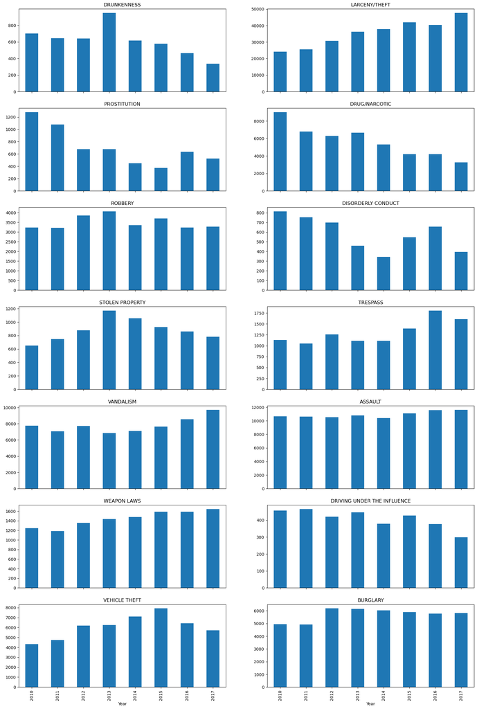

```python
fig, axs = plt.subplots(7,2,figsize=(20,30),sharex=True)
for i,category in enumerate(focuscrimes):
    category_counts = pivot.loc[category]
    category_counts.plot(kind='bar',title=category, ax=axs[i//2,i%2],legend=False)

fig.savefig("image.png")
```

Additionly, we have also observed a remarkable surge in `DRUNKENNESS` incidents in 2013, which raises questions about what may have caused this spike, as well as the reasons for the subsequent sharp decline in drug-related crime incidents in the following year. Further exploration of these phenomena is definitely warranted.

Therefore, let's focus solely on `LARCANY/THEFT` crimes in our analysis to better understand what occurred within this category and potentially gain some insightful findings.

## Map

Plot a Map of San Francisco

```python
lat = 37.773972
lon = -122.431297
sf = folium.Map([lat, lon], tiles='Stamen Terrain', zoom_start=13)
display(sf)
```

Make this Notebook Trusted to load map: File -> Trust Notebook

[interactive chart not shown]

```python
df_focus['Hour'] = pd.to_datetime(df_focus['Time']).dt.hour
df_focus['HourOfWeek']= pd.to_datetime(df_focus['Date']).dt.dayofweek * 24 + df_focus['Hour']
df_theft = df_focus[df_focus['Category'].isin(['LARCENY/THEFT'])].reset_index(drop=True)
df_theft = df_theft [df_theft['Year'].isin(['2017','2018'])]
```

```python
temp_data = df_theft[['Y', 'X','HourOfWeek']]
temp_data = temp_data.dropna(axis=0, subset=['Y','X','HourOfWeek'])
heat_data = [[[ row['Y'],row['X']] for index, row in temp_data[temp_data['HourOfWeek'] == i].iterrows()] for i in range(0,166)]
```

```python
sf = folium.Map([lat, lon], tiles='Stamen Toner', zoom_start=13)
hm = plugins.HeatMapWithTime(heat_data, auto_play=True,
                             radius=12,
                             min_opacity=0.5,
                             max_opacity=0.8,
                             gradient={0.2: 'blue', 0.4: 'lime', 0.6: 'orange', 1: 'red'},
                             use_local_extrema=True)
hm.add_to(sf)
display(sf)
```

Make this Notebook Trusted to load map: File -> Trust Notebook

[interactive chart not shown]

After analyzing the map we created, it is evident that the western northern part of San Francisco, particularly the Central, Northern, Southern, and Mission districts, have the highest crime rates. One possible explanation for this trend is that these areas are located in the downtown part of the city, where there is a larger influx of people and higher population density. This creates more opportunities for criminal activity, which may explain the prevalence of crime in these districts.

Upon closer examination of the map, it becomes apparent that certain streets within these districts have a disproportionately high number of crimes. This could be due to the presence of popular tourist attractions, such as shopping centers and scenic spots, that attract large crowds and provide more opportunities for crime to occur.

We propose that additional police resources be allocated to these neighborhoods and streets in order to reduce criminal activity as a solution to this problem. In order to keep an eye out for suspicious activity, some possible strategies that could be used include stepping up foot patrols, setting up security cameras, and collaborating with nearby businesses. It is crucial to remember, however, that this strategy must be used cautiously to prevent potential drawbacks like excessive policing and strained community relations.

We find another interesting trend in the timing of crime incidents in San Francisco. Specifically, we have observed a sharp increase in the number of crimes occurring between 7:00 PM and 9:00 PM each day, followed by a rapid decline after 10:00 PM. One possible explanation for this pattern is that the early evening hours are when the city experiences the highest influx of people, making it an opportune time for criminals to strike. However, after 10:00 PM, the number of people on the streets diminishes, reducing the likelihood of criminal activity. Given this trend, we suggest that allocating additional police resources during the 7:00 PM to 9:00 PM timeframe may be an effective strategy for reducing crime rates during these peak hours.

# Boken viz

```python
df_theft = df_focus[df_focus["Category"].isin(['LARCENY/THEFT'])]
counts = df_theft.groupby(["PdDistrict","Year"]).size().reset_index(name = "counts")
```

```python
df_theft
```

|  | PdId | IncidntNum | Incident Code | Category | Descript | DayOfWeek | Date | Time | PdDistrict | Resolution | ... | CBD, BID and GBD Boundaries as of 2017 2 2 | Areas of Vulnerability, 2016 2 2 | Central Market/Tenderloin Boundary 2 2 | Central Market/Tenderloin Boundary Polygon - Updated 2 2 | HSOC Zones as of 2018-06-05 2 2 | OWED Public Spaces 2 2 | Neighborhoods 2 | Year | Hour | HourOfWeek |
| --- | --- | --- | --- | --- | --- | --- | --- | --- | --- | --- | --- | --- | --- | --- | --- | --- | --- | --- | --- | --- | --- |
| 11 | 12620267506244 | 126202675 | 6244 | LARCENY/THEFT | GRAND THEFT FROM LOCKED AUTO | Friday | 12/21/2012 | 19:15 | CENTRAL | NONE | ... | NaN | 2.0 | NaN | NaN | NaN | NaN | 104.0 | 2012 | 19 | 115 |
| 16 | 10018088906362 | 100180889 | 6362 | LARCENY/THEFT | PETTY THEFT SHOPLIFTING | Tuesday | 02/23/2010 | 17:57 | SOUTHERN | ARREST, CITED | ... | 5.0 | 2.0 | NaN | NaN | NaN | 35.0 | 32.0 | 2010 | 17 | 41 |
| 19 | 12601807406374 | 126018074 | 6374 | LARCENY/THEFT | GRAND THEFT OF PROPERTY | Monday | 02/06/2012 | 18:00 | MISSION | NONE | ... | 9.0 | 1.0 | NaN | NaN | 5.0 | NaN | 28.0 | 2012 | 18 | 18 |
| 25 | 12607802806372 | 126078028 | 6372 | LARCENY/THEFT | PETTY THEFT OF PROPERTY | Saturday | 06/02/2012 | 13:00 | NORTHERN | NONE | ... | NaN | 1.0 | NaN | NaN | NaN | NaN | 27.0 | 2012 | 13 | 133 |
| 35 | 13617083006372 | 136170830 | 6372 | LARCENY/THEFT | PETTY THEFT OF PROPERTY | Wednesday | 09/11/2013 | 16:00 | CENTRAL | NONE | ... | NaN | 2.0 | NaN | NaN | NaN | NaN | 108.0 | 2013 | 16 | 64 |
| ... | ... | ... | ... | ... | ... | ... | ... | ... | ... | ... | ... | ... | ... | ... | ... | ... | ... | ... | ... | ... | ... |
| 2129500 | 17601296306244 | 176012963 | 6244 | LARCENY/THEFT | GRAND THEFT FROM LOCKED AUTO | Wednesday | 01/11/2017 | 18:40 | CENTRAL | NONE | ... | 2.0 | 2.0 | NaN | NaN | NaN | NaN | 99.0 | 2017 | 18 | 66 |
| 2129501 | 16105518806244 | 161055188 | 6244 | LARCENY/THEFT | GRAND THEFT FROM LOCKED AUTO | Wednesday | 12/28/2016 | 22:34 | CENTRAL | NONE | ... | NaN | 2.0 | NaN | NaN | NaN | NaN | 50.0 | 2016 | 22 | 70 |
| 2129504 | 17606126106244 | 176061261 | 6244 | LARCENY/THEFT | GRAND THEFT FROM LOCKED AUTO | Monday | 03/06/2017 | 00:20 | PARK | NONE | ... | NaN | 1.0 | NaN | NaN | NaN | NaN | 112.0 | 2017 | 0 | 0 |
| 2129505 | 17024208306244 | 170242083 | 6244 | LARCENY/THEFT | GRAND THEFT FROM LOCKED AUTO | Friday | 03/24/2017 | 13:30 | NORTHERN | NONE | ... | NaN | 1.0 | NaN | NaN | NaN | 15.0 | 17.0 | 2017 | 13 | 109 |
| 2129507 | 16614037006244 | 166140370 | 6244 | LARCENY/THEFT | GRAND THEFT FROM LOCKED AUTO | Monday | 06/20/2016 | 17:30 | PARK | NONE | ... | NaN | 1.0 | NaN | NaN | NaN | NaN | 97.0 | 2016 | 17 | 17 |

284736 rows × 38 columns

```python
counts = df_theft.groupby(["PdDistrict","Year"]).size().reset_index(name = "counts")
pivot = counts.pivot(index = "Year", columns = "PdDistrict", values = "counts")
```

```python
pivot
```

| PdDistrict Year | BAYVIEW | CENTRAL | INGLESIDE | MISSION | NORTHERN | PARK | RICHMOND | SOUTHERN | TARAVAL | TENDERLOIN |
| --- | --- | --- | --- | --- | --- | --- | --- | --- | --- | --- |
| 2010 | 1593 | 3401 | 1641 | 2884 | 3294 | 1134 | 1191 | 6326 | 1511 | 1237 |
| 2011 | 1443 | 3559 | 1653 | 3325 | 3622 | 1373 | 1334 | 6014 | 1908 | 1398 |
| 2012 | 1804 | 4208 | 1805 | 3603 | 4579 | 1818 | 1773 | 7568 | 2064 | 1538 |
| 2013 | 2203 | 4884 | 2081 | 4246 | 5687 | 2033 | 2251 | 8780 | 2265 | 1786 |
| 2014 | 2016 | 5766 | 2065 | 3244 | 6323 | 2219 | 2146 | 9995 | 2221 | 1865 |
| 2015 | 2209 | 6908 | 2003 | 2403 | 7463 | 2375 | 2976 | 10908 | 2721 | 2014 |
| 2016 | 2357 | 6736 | 1782 | 3332 | 7218 | 2222 | 3133 | 9181 | 2595 | 1808 |
| 2017 | 2739 | 8166 | 2039 | 5515 | 8877 | 2411 | 3408 | 9979 | 2930 | 1650 |

```python
normal = pivot.copy()
normal = normal.astype(float)

for i in range(pivot.shape[1]):
    for j in range(pivot.shape[0]):
        normal.iloc[:,i][j] = pivot.iloc[:,i][j] / sum(pivot.iloc[:,i])
```

```python
normal
```

| PdDistrict Year | BAYVIEW | CENTRAL | INGLESIDE | MISSION | NORTHERN | PARK | RICHMOND | SOUTHERN | TARAVAL | TENDERLOIN |
| --- | --- | --- | --- | --- | --- | --- | --- | --- | --- | --- |
| 2010 | 0.097348 | 0.077955 | 0.108899 | 0.101009 | 0.069991 | 0.072762 | 0.065396 | 0.092013 | 0.082954 | 0.093035 |
| 2011 | 0.088181 | 0.081576 | 0.109695 | 0.116454 | 0.076961 | 0.088098 | 0.073248 | 0.087475 | 0.104749 | 0.105144 |
| 2012 | 0.110242 | 0.096452 | 0.119782 | 0.126191 | 0.097295 | 0.116651 | 0.097353 | 0.110078 | 0.113313 | 0.115674 |
| 2013 | 0.134625 | 0.111946 | 0.138098 | 0.148711 | 0.120838 | 0.130446 | 0.123600 | 0.127707 | 0.124348 | 0.134326 |
| 2014 | 0.123197 | 0.132163 | 0.137036 | 0.113617 | 0.134352 | 0.142380 | 0.117834 | 0.145380 | 0.121932 | 0.140268 |
| 2015 | 0.134991 | 0.158339 | 0.132922 | 0.084162 | 0.158575 | 0.152390 | 0.163409 | 0.158660 | 0.149382 | 0.151474 |
| 2016 | 0.144036 | 0.154396 | 0.118256 | 0.116699 | 0.153369 | 0.142573 | 0.172029 | 0.133540 | 0.142465 | 0.135981 |
| 2017 | 0.167380 | 0.187173 | 0.135311 | 0.193156 | 0.188620 | 0.154700 | 0.187129 | 0.145147 | 0.160856 | 0.124097 |

```python
from bokeh.io import output_notebook, show
source = ColumnDataSource(normal)
output_notebook()
```

```python
p = figure(x_range=FactorRange(factors=normal.index),
           plot_width=1200,
           title='Crimes By year',
           x_axis_label='Year',
           y_axis_label='Relative Frequency')
```

```python
cmap = sns.color_palette('icefire', len(normal.columns)).as_hex()
```

```python
district_lsit = list(df_focus['PdDistrict'].unique())
district_lsit.remove(district_lsit[-1])
```

```python
bar = {}
items = []

for i, district in enumerate(district_lsit):
    bar[district] = p.vbar(x='Year',
                    top=district,
                    source=source,
                    width=0.7,
                    color=cmap[i],
                    fill_alpha=1.5,
                    muted=True,
                    muted_alpha=0.005)
    items.append((district, [bar[district]]))

p.xaxis.major_label_orientation = 1
p.y_range.start = 0
```

```python
legend = Legend(items=items)
p.add_layout(legend, 'left')
p.legend.click_policy = 'mute'

show(p)
```

[interactive chart not shown]

```python
output_file('my_bokeh_visualization.html')
save(p)
```

```
'C:\\Users\\geng8\\Desktop\\Exercise4\\my_bokeh_visualization.html'
```